# Tarea Diplomado: Análisis de caso: Mortalidad en MarineFjordland en 2021

# 2.9.- QQplot para ver la normalidad de los datos Densidad de cultivo

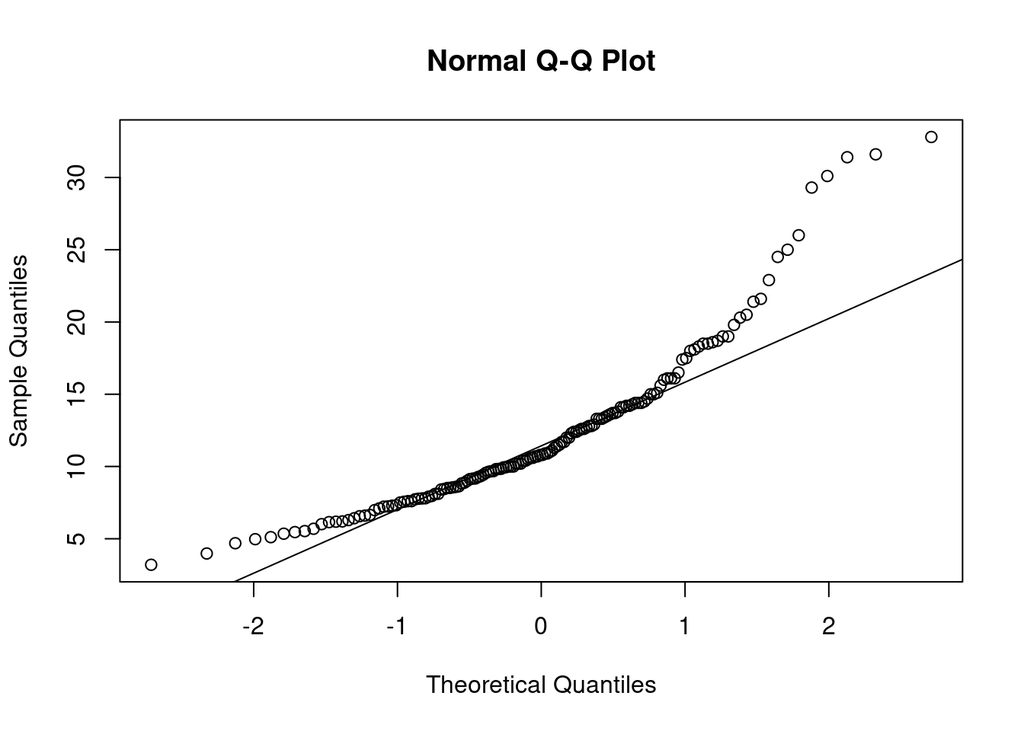

```r
qqnorm(D$Density)
qqline(D$Density)
```

# De acuerdo a lo que vemos en el qqplot, los datos de Densidad no tienen una distribución normal y tienen una asimetría hacia la derecha.

# 2.10.- Prueba de Kolmogorov-Smirnov en la variable Densidad

```r
ks.test(D$Density, "pnorm")
```

```
##
##  Asymptotic one-sample Kolmogorov-Smirnov test
##
## data:  D$Density
## D = 0.99931, p-value < 2.2e-16
## alternative hypothesis: two-sided
```

```r
ks.test(D$Case, "pnorm")
```

```
##
##  Asymptotic one-sample Kolmogorov-Smirnov test
##
## data:  D$Case
## D = 0.5, p-value < 2.2e-16
## alternative hypothesis: two-sided
```

#2.11.- Preguntas Adicionales: Hipotesis nula ¿La mortalidad observada en los casos positivos está explicada por tipo de vacuna, zona de manejo, temperatura promedio del agua, densidad de cultivo, compañia productora,enfermedad de branquias, presencia de caligus, calidad de smolt?

# 2.12.- Comentario Final al analisis exploratorio de datos

La base de datos está limpia, completa, existen variables cualitativas y cuantitativas. La variables cuantitativas no tienen una distribución normal por ende se requiere pruebas no parametricas para un adecuado análisis estadistico.

## 3.- Propuesta de Hipotesis

La propuesta de la hipotesis se hizo considerando sólo la relación entre Densidad y Caso

Hipotesis 0: La densidad no esta asociada al caso(1) Hipotesis 1: La densidad está asociada al caso (1)

Para evaluar la correlación entre dos variables cuantitativas y no parametricas se utilizará la coeficiente rho de Spearman.

```r
cor.test(x=D$Density, y=D$Case, method='spearman')
```

```
##
##  Spearman's rank correlation rho
##
## data:  D$Density and D$Case
## S = 376818, p-value = 3.708e-05
## alternative hypothesis: true rho is not equal to 0
## sample estimates:
##      rho
## 0.330072
```

Escala Spearman:

Correlación negativa perfecta………………………….. -1

Correlación negativa fuerte moderada débil…………… -0,5

Ninguna correlación……………………………………. 0

Correlación positiva moderada Fuerte…………………. +0,5

Correlación positiva perfecta…………………………… + 1

La interpretación del coeficiente rho de Spearman concuerda en valores próximos a 1; indican una correlación fuerte y positiva. Valores próximos a –1 indican una correlación fuerte y negativa. Valores próximos a cero indican que no hay correlación lineal. En este caso hay correlacion positiva moderada, pero no lineal. Y el P value es menor a 0,5 por lo tanto se acepta la hipotesis alternativa es decir hay correlación entre caso (1) y densidad.

## 4.- Evaluación de supuestos

# 4.1.-Homocedasticidad

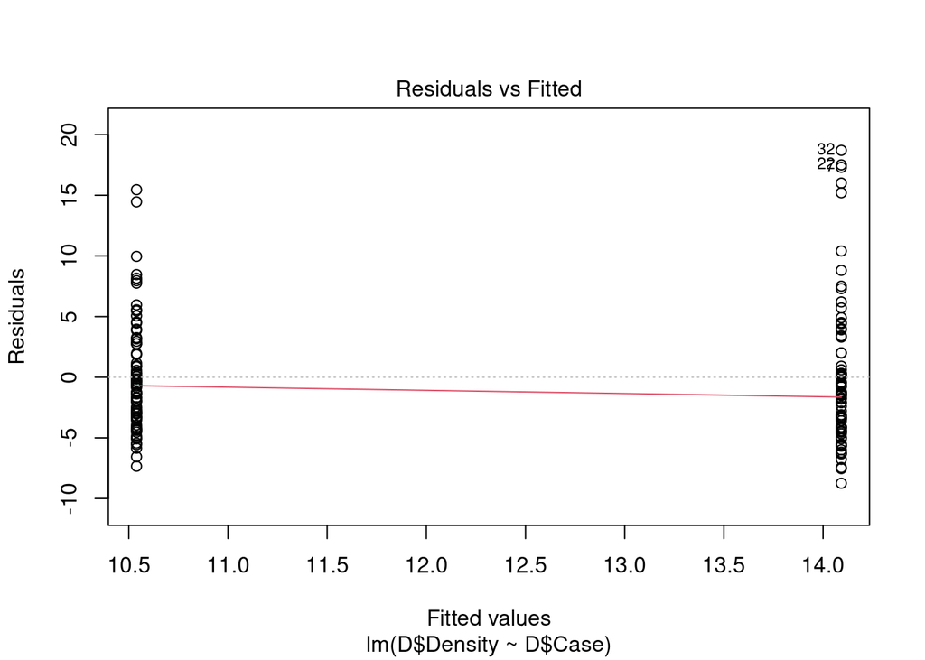

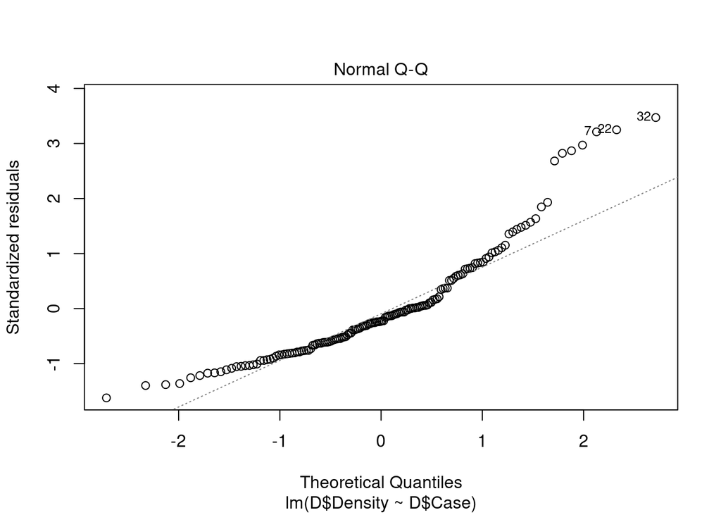

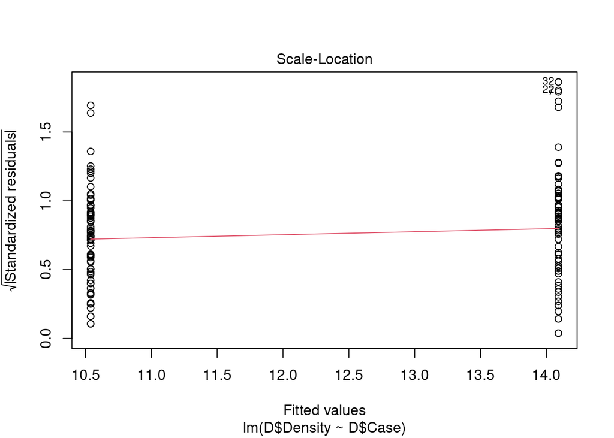

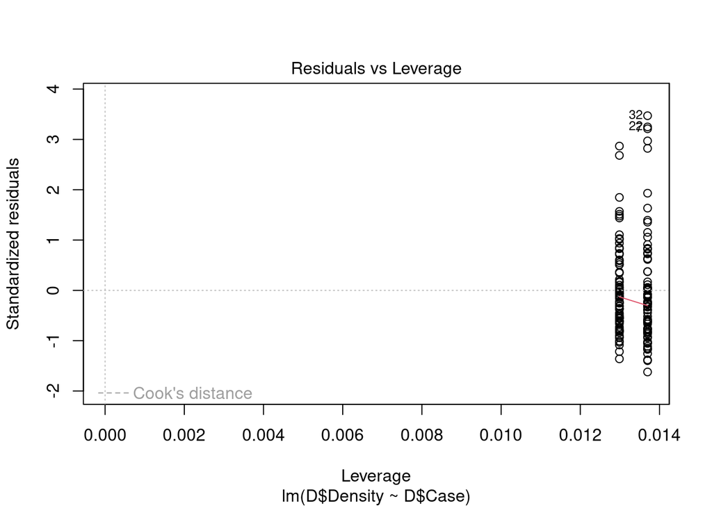

```r
lm1<-lm(D$Density~ D$Case)
plot(lm1)
```

# 4.2.-Independencia

Se evalua con Residuales

```r
lm.aov <- lm(D$Density ~D$Case , data = D)
aov(lm.aov)
```

```
## Call:
##    aov(formula = lm.aov)
##
## Terms:
##                   D$Case Residuals
## Sum of Squares   473.081  4359.092
## Deg. of Freedom        1       148
##
## Residual standard error: 5.427092
## Estimated effects may be unbalanced
```

Y con la prueba de DURBIN-WATSON #H0: Son independientes. #H1: No son independientes.

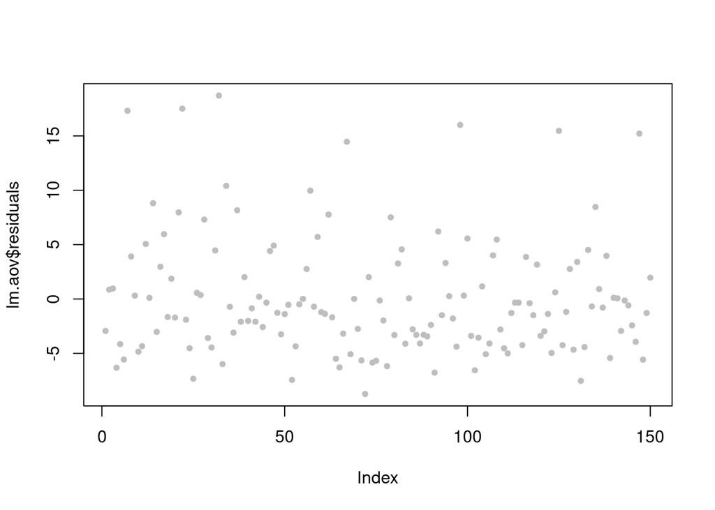

```r
plot(lm.aov$residuals, pch=20, col = "grey")
```

```r
dwtest(D$Density ~D$Case , data = D,
       alternative = c("two.sided"),
       iterations = 15)
```

```
##
##  Durbin-Watson test
##
## data:  D$Density ~ D$Case
## DW = 2.1379, p-value = 0.3973
## alternative hypothesis: true autocorrelation is not 0
```

# 4.3.- Normalidad

- Se analizó en el analisis exploratorio mediante el qq-plot

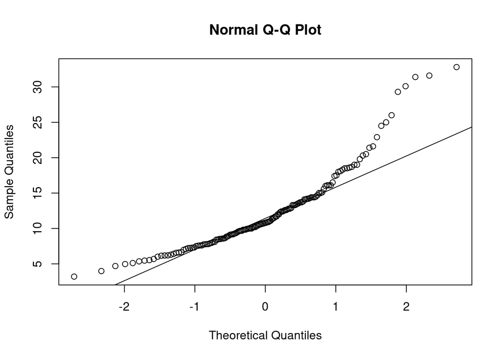

```r
qqnorm(D$Density)
qqline(D$Density)
```

Y mediante el Test de Shapiro

```r
shapiro.test(x=D$Density )
```

```
##
##  Shapiro-Wilk normality test
##
## data:  D$Density
## W = 0.8893, p-value = 3.439e-09
```

## 5.- Conclusiones

- Se acepta la hipotesis alternativa (hay correlación entre Densidad y Caso), la correlacion es positiva moderada, y muy posiblemente no lineal.
- De acuerdo con AED, la información disponible permite realizar un adecuado análisis estadístico.